# Escaped Muons

Adam Lyon

2017-03-10

# Introduction

Part of the Accelerator Readiness Review is looking at muons that leave the ring. To this end, we (Renee, Nathan, James, and myself) have a preliminary version of MDC-2 with full injection, unified fields, and “ghost” detectors in a Geant parallel world (so these sensitive volumes can be placed without overlapping physical structures). We can remove various magnets and fields and see how that affects muons escaping the beam.

```r
# Load libraries
library(readGallery)
library(stringr)
library(dplyr)
library(ggplot2)
library(rgl)
```

# Samples

I have run preliminary MDC-2 (using Renee’s FCL files), making 10K events for various scenarios. Files are currently stored in `/pnfs/GM2/scratch/users/lyon/arr_20170313` and directories within. Ghost detectors included are Renee’s cylinder just at the outer vacuum wall and encompossing the inflector as well as my ghost detector that is a cylindrical shell just on the inside of the world cube. Note that this code includes the magnet yoke steel.

## Find the data

```r
# Let's look at only the 180* job series (so we just get 10,000 events per scenario)
system('ifdh ls /pnfs/GM2/scratch/users/lyon/arr_20170313/180*/*.root | grep .root', intern=T) %>%
  xrootify() -> arrFiles
arrFiles
```

```
[1] "root://fndca1.fnal.gov/pnfs/fnal.gov/usr/GM2/scratch/users/lyon/arr_20170313/18089099_0/ARR_unified_noKickerQuads_cyl.root"
[2] "root://fndca1.fnal.gov/pnfs/fnal.gov/usr/GM2/scratch/users/lyon/arr_20170313/18089123_0/ARR_unified_noKicker_cyl.root"
[3] "root://fndca1.fnal.gov/pnfs/fnal.gov/usr/GM2/scratch/users/lyon/arr_20170313/18089132_0/ARR_unified_noQuads_cyl.root"
[4] "root://fndca1.fnal.gov/pnfs/fnal.gov/usr/GM2/scratch/users/lyon/arr_20170313/18089097_0/ARR_unified_noInflector_cyl.root"
[5] "root://fndca1.fnal.gov/pnfs/fnal.gov/usr/GM2/scratch/users/lyon/arr_20170313/18089092_0/ARR_unified_everything_cyl.root"
[6] "root://fndca1.fnal.gov/pnfs/fnal.gov/usr/GM2/scratch/users/lyon/arr_20170313/18089095_0/ARR_unified_noDipole_cyl.root"
```

Let’s pluck out the scenario.

```r
scenarios <- str_match(arrFiles, 'arr_20170313/.+_unified_(.+)_cyl')[,2]
scenarios
```

```
[1] "noKickerQuads" "noKicker"      "noQuads"       "noInflector"   "everything"    "noDipole"
```

What data are in these file? Well, `product_sizes_dumper` doesn’t seem to work across XRootD. That’s too bad.

Here’s a picture from Root.

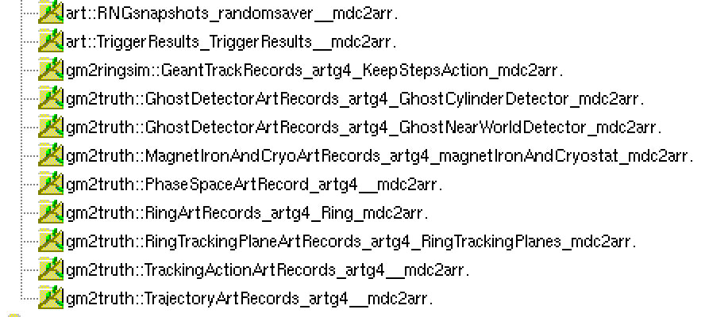

## Look at Tracking action data to see how mnay muons decay and how many escape

```r
useDataProduct('std::vector<gm2truth::TrackingActionArtRecord>')
```

Create a reader class (modify outside of this notebook) for TrackingActionArtRecord

```r
readerClassSkel('gm2truth::TrackingActionArtRecord', writeFile = 'trackingActionReader.py')
```

### `trackingActionReader`

For documentation, here is the `TrackingActionArtRecordReader` reader class

```r
readr::read_file('trackingActionReader.py') %>% cat
```

```
from readGallery import GalleryReaderBase  # Necessary for the base class

class TrackingActionArtRecordReader(GalleryReaderBase):
  def __init__(self, inputTag, evLimit):
    GalleryReaderBase.__init__(self, inputTag)
    self.names = ['fileEntry', 'eventEntry', 'trackType', 'trackID',
                  'parentTrackID', 'volumeUID', 'status', 'x', 'y', 'z', 'px', 'py', 'pz']
    self.evLimit = evLimit

  def prepare(self, ROOT, ev):
    GalleryReaderBase.prepare(self, ROOT, ev)
    self.getValidHandle = ev.getValidHandle(ROOT.vector(ROOT.gm2truth.TrackingActionArtRecord))

  def fill(self, ROOT, ev):

    if ev.eventEntry() > self.evLimit:
      return False

    validHandle = self.getValidHandle(self.inputTag)  # Get the valid handle for gm2truth::TrackingActionArtRecord

    if not validHandle.empty():                       # Does it have data?

      p = validHandle.product()                       # Get the corresponding data product (maybe a vector)

      # Fill from gm2truth::TrackingActionArtRecord
      for e in p:                             # Loop over elements and fill

        # Let's only accept the muon
        if e.trackID != 1 or e.parentTrackID != 0:
          continue

        self.vals.append(
          [ ev.fileEntry(), ev.eventEntry(), e.trackType, e.trackID, e.parentTrackID,  e.volumeUID,
            e.status, e.x, e.y, e.z, e.px, e.py, e.pz ])

    return True
```

Make an instance

```r
trackingActionReaderClass <- createReaderClass_from_file('trackingActionReader.py')$TrackingActionArtRecordReader
```

```r
taReader <- trackingActionReaderClass(artInputTag("artg4"), 20000)
getGalleryData(arrFiles[1], taReader)
```

[output not shown]

[output not shown]

As of right now, the dCache XRootD door is done.

```r
nrow(taDF)
```

```
[1] 120000
```

Set the scenario (we’ll need that again, so make it a function)

```r
setScenario <- function(df) {
  df %>% mutate(scenario = factor(fileEntry, levels=0:(length(scenarios)-1), labels=scenarios))
}
```

```r
taDF %>% setScenario() %>% select(scenario, everything()) -> taDF
taDF
```

| scenario | fileEntry | eventEntry | trackType | trackID | parentTrackID | volumeUID | status | x | y | z | px | py | pz |
| --- | --- | --- | --- | --- | --- | --- | --- | --- | --- | --- | --- | --- | --- |
| noKickerQuads | 0 | 0 | mu+ | 1 | 0 | 0 | 0 | 6691.036 | -1.753027e+00 | -5031.30945 | 673.59765 | 2.51350197 | 3020.35276 |
| noKickerQuads | 0 | 0 | mu+ | 1 | 0 | 3 | 1 | 7618.018 | 3.202005e+02 | -2516.57908 | 0.00000 | 0.00000000 | 0.00000 |
| noKickerQuads | 0 | 1 | mu+ | 1 | 0 | 0 | 0 | 6643.655 | 1.797274e+00 | -5020.15283 | 716.16383 | -1.52943880 | 3008.95487 |
| noKickerQuads | 0 | 1 | mu+ | 1 | 0 | 1 | 1 | 7662.048 | 1.823433e+01 | -2266.61577 | 0.00000 | 0.00000000 | 0.00000 |
| noKickerQuads | 0 | 2 | mu+ | 1 | 0 | 0 | 0 | 6652.941 | 1.648958e+00 | -5022.33933 | 711.44245 | -8.84182050 | 3009.61871 |
| noKickerQuads | 0 | 2 | mu+ | 1 | 0 | 1 | 1 | 7748.935 | 2.065622e+02 | -2414.98949 | 0.00000 | 0.00000000 | 0.00000 |
| noKickerQuads | 0 | 3 | mu+ | 1 | 0 | 0 | 0 | 6675.685 | -1.175225e+01 | -5027.69493 | 684.60683 | 27.75851040 | 3018.74557 |
| noKickerQuads | 0 | 3 | mu+ | 1 | 0 | 1 | 1 | 7443.388 | 1.333376e+02 | -2455.37838 | 0.00000 | 0.00000000 | 0.00000 |
| noKickerQuads | 0 | 4 | mu+ | 1 | 0 | 0 | 0 | 6656.017 | 3.311572e-01 | -5023.06364 | 705.87306 | 0.52297634 | 3015.03958 |
| noKickerQuads | 0 | 4 | mu+ | 1 | 0 | 2 | 1 | 10000.000 | 5.643123e+02 | -1493.51552 | 129.82073 | 18.73014197 | 62.59531 |

[output cut: 990 more lines]

How many track action hits do we get per scenario.

```r
taDF %>% group_by(scenario) %>% tally()
```

| scenario | n |
| --- | --- |
| noKickerQuads | 20000 |
| noKicker | 20000 |
| noQuads | 20000 |
| noInflector | 20000 |
| everything | 20000 |
| noDipole | 20000 |

Let’s just get the death of the muons.

### Muon deaths in tracking action

```r
taDF %>% filter(status == 1) -> taDeathDF
```

We need the volume ID. I have a art FCL to run to get this information. I have files and they each may have a different set of volume IDs. Let’s try to do this in parallel. The examples in the help for `parallel::mcparallel` seem to be useful here.

Create the command strings,

```r
runForVolIDString <- function(i) {
  str_interp(
    "PVS_CSVOUT=${csvout}_volNames.csv gm2 -c ${fclPath}/gm2analyses/fcl/physicalVolumeStoreToFile.fcl -n 1 ${aFile}",
    list( csvout=scenarios[i], fclPath=Sys.getenv("MRB_BUILDDIR"), aFile=arrFiles[i])
  )
}
runForVolIDStrings <- sapply(1:length(arrFiles), runForVolIDString)
runForVolIDStrings
```

```
[1] "PVS_CSVOUT=noKickerQuads_volNames.csv gm2 -c /home/me/gm2/renee_arr/build_slf7.x86_64/gm2analyses/fcl/physicalVolumeStoreToFile.fcl -n 1 root://fndca1.fnal.gov/pnfs/fnal.gov/usr/GM2/scratch/users/lyon/arr_20170313/18089099_0/ARR_unified_noKickerQuads_cyl.root"
[2] "PVS_CSVOUT=noKicker_volNames.csv gm2 -c /home/me/gm2/renee_arr/build_slf7.x86_64/gm2analyses/fcl/physicalVolumeStoreToFile.fcl -n 1 root://fndca1.fnal.gov/pnfs/fnal.gov/usr/GM2/scratch/users/lyon/arr_20170313/18089123_0/ARR_unified_noKicker_cyl.root"
[3] "PVS_CSVOUT=noQuads_volNames.csv gm2 -c /home/me/gm2/renee_arr/build_slf7.x86_64/gm2analyses/fcl/physicalVolumeStoreToFile.fcl -n 1 root://fndca1.fnal.gov/pnfs/fnal.gov/usr/GM2/scratch/users/lyon/arr_20170313/18089132_0/ARR_unified_noQuads_cyl.root"
[4] "PVS_CSVOUT=noInflector_volNames.csv gm2 -c /home/me/gm2/renee_arr/build_slf7.x86_64/gm2analyses/fcl/physicalVolumeStoreToFile.fcl -n 1 root://fndca1.fnal.gov/pnfs/fnal.gov/usr/GM2/scratch/users/lyon/arr_20170313/18089097_0/ARR_unified_noInflector_cyl.root"
[5] "PVS_CSVOUT=everything_volNames.csv gm2 -c /home/me/gm2/renee_arr/build_slf7.x86_64/gm2analyses/fcl/physicalVolumeStoreToFile.fcl -n 1 root://fndca1.fnal.gov/pnfs/fnal.gov/usr/GM2/scratch/users/lyon/arr_20170313/18089092_0/ARR_unified_everything_cyl.root"
[6] "PVS_CSVOUT=noDipole_volNames.csv gm2 -c /home/me/gm2/renee_arr/build_slf7.x86_64/gm2analyses/fcl/physicalVolumeStoreToFile.fcl -n 1 root://fndca1.fnal.gov/pnfs/fnal.gov/usr/GM2/scratch/users/lyon/arr_20170313/18089095_0/ARR_unified_noDipole_cyl.root"
```

Let’s run in parallel

```r
jobs <- lapply(1:length(arrFiles), function(i) mcparallel(system( runForVolIDStrings[i], intern=T ), name=i))
res <- mccollect(jobs)
```

Now we need to load the csv files. Let’s do that in parallel too

```r
jobs <- lapply(1:length(arrFiles), function(i) paste0(scenarios[i], "_volNames.csv") %>% read_csv(col_names=c("volumeUID", "volName")) %>% mcparallel(name=i) )
volNameTables <- mccollect(jobs)
names(volNameTables) <- scenarios
```

Let’s see what we got

```r
volNameTables[["everything"]]
```

| volumeUID | volName |
| --- | --- |
| 0 | ArcSection[00] |
| 1 | RingYokeBackleg |
| 2 | world |
| 3 | RingYokeTop |
| 4 | RingCryoOuter |
| 5 | RingPoleTipLower |
| 6 | RingYokeBottom |
| 7 | RingPoleTipUpper |
| 8 | VacuumChamberCadMeshWallPV[11] |
| 9 | RingInnerCryostatLower |

[output cut: 45 more lines]

Join them together when the scenario name.

```r
volNameTable <- map2_df(volNameTables, scenarios, function(df, sce) df %>% mutate(scenario = sce) )
volNameTable
```

| volumeUID | volName | scenario |
| --- | --- | --- |
| 0 | ArcSection[00] | noKickerQuads |
| 1 | RingYokeBackleg | noKickerQuads |
| 2 | world | noKickerQuads |
| 3 | RingYokeTop | noKickerQuads |
| 4 | RingCryoOuter | noKickerQuads |
| 5 | RingYokeBottom | noKickerQuads |
| 6 | RingPoleTipUpper | noKickerQuads |
| 7 | RingInnerCryostatUpper | noKickerQuads |
| 8 | VacuumChamberCadMeshWallPV[11] | noKickerQuads |
| 9 | RingPoleTipLower | noKickerQuads |

[output cut: 333 more lines]

Now let’s do lookups… [Note that I can’t do what I originally thought, which was split up the data frame into groups by scenario and then put in the factor by group – because in the end the rows get rejoined and then row-binded factor gets messed up.]

```r
taDeathDF -> hold # in case we mess up
taDeathDF %>% inner_join(volNameTable) %>% select(scenario, eventEntry, volName, everything()) -> taDeathDF
```

```
joining factor and character vector, coercing into character vector
```

```r
taDeathDF
```

| scenario | eventEntry | volName | fileEntry | trackType | trackID | parentTrackID | volumeUID | status | x | y | z | px | py | pz |
| --- | --- | --- | --- | --- | --- | --- | --- | --- | --- | --- | --- | --- | --- | --- |
| noKickerQuads | 0 | RingYokeTop | 0 | mu+ | 1 | 0 | 3 | 1 | 7618.018 | 320.2004549 | -2516.57908 | 0.00000 | 0.000000 | 0.00000 |
| noKickerQuads | 1 | RingYokeBackleg | 0 | mu+ | 1 | 0 | 1 | 1 | 7662.048 | 18.2343298 | -2266.61577 | 0.00000 | 0.000000 | 0.00000 |
| noKickerQuads | 2 | RingYokeBackleg | 0 | mu+ | 1 | 0 | 1 | 1 | 7748.935 | 206.5621595 | -2414.98949 | 0.00000 | 0.000000 | 0.00000 |
| noKickerQuads | 3 | RingYokeBackleg | 0 | mu+ | 1 | 0 | 1 | 1 | 7443.388 | 133.3376049 | -2455.37838 | 0.00000 | 0.000000 | 0.00000 |
| noKickerQuads | 4 | world | 0 | mu+ | 1 | 0 | 2 | 1 | 10000.000 | 564.3123386 | -1493.51552 | 129.82073 | 18.730142 | 62.59531 |
| noKickerQuads | 5 | RingYokeBackleg | 0 | mu+ | 1 | 0 | 1 | 1 | 7544.831 | -82.3761049 | -2683.92232 | 0.00000 | 0.000000 | 0.00000 |
| noKickerQuads | 6 | RingYokeBackleg | 0 | mu+ | 1 | 0 | 1 | 1 | 7643.492 | 46.1150165 | -2484.33151 | 0.00000 | 0.000000 | 0.00000 |
| noKickerQuads | 7 | RingYokeBackleg | 0 | mu+ | 1 | 0 | 1 | 1 | 7560.616 | -185.2019618 | -2152.17009 | 0.00000 | 0.000000 | 0.00000 |
| noKickerQuads | 8 | RingYokeBackleg | 0 | mu+ | 1 | 0 | 1 | 1 | 7571.393 | -123.1081822 | -2598.59679 | 0.00000 | 0.000000 | 0.00000 |
| noKickerQuads | 9 | RingYokeBackleg | 0 | mu+ | 1 | 0 | 1 | 1 | 7620.787 | 42.8125505 | -2285.44959 | 0.00000 | 0.000000 | 0.00000 |

[output cut: 990 more lines]

We can check this – we should see different volume names associated with volume IDs for different scenarios

```r
taDeathDF %>% distinct(scenario, volumeUID, volName) %>% arrange(volumeUID)
```

| scenario | volumeUID | volName |
| --- | --- | --- |
| noInflector | 0 | ArcSection[00] |
| noKickerQuads | 1 | RingYokeBackleg |
| noKicker | 1 | RingYokeBackleg |
| noQuads | 1 | RingYokeBackleg |
| noInflector | 1 | RingYokeBackleg |
| everything | 1 | RingYokeBackleg |
| noDipole | 1 | RingYokeBackleg |
| noKickerQuads | 2 | world |
| noKicker | 2 | RingCryoOuter |
| noInflector | 2 | RingCryoOuter |

[output cut: 48 more lines]

Let’s plot where things die

```r
taDeathDF %>% group_by(scenario, volName) %>% tally() %>% arrange(scenario, desc(n)) -> deathVolumeTable
deathVolumeTable
```

| scenario | volName | n |
| --- | --- | --- |
| everything | RingYokeBackleg | 8899 |
| everything | RingCryoOuter | 445 |
| everything | RingYokeTop | 231 |
| everything | world | 227 |
| everything | RingYokeBottom | 183 |
| everything | RingPoleTipLower | 6 |
| everything | RingPoleTipUpper | 5 |
| everything | InflectorMandrel | 3 |
| everything | VacuumChamberCadMeshWallPV[11] | 1 |
| noDipole | RingYokeBackleg | 8919 |

[output cut: 48 more lines]

Did any of them actually decay?

```r
taDeathDF %>% filter(volName == "ArcSection[00]")
```

| scenario | eventEntry | volName | fileEntry | trackType | trackID | parentTrackID | volumeUID | status | x | y | z | px | py | pz |
| --- | --- | --- | --- | --- | --- | --- | --- | --- | --- | --- | --- | --- | --- | --- |
| noInflector | 300 | ArcSection[00] | 3 | mu+ | 1 | 0 | 0 | 1 | 6748.015 | -4.223349 | -4576.117 | 720.649 | 28.45812 | 3005.27 |

Uh oh!!!!

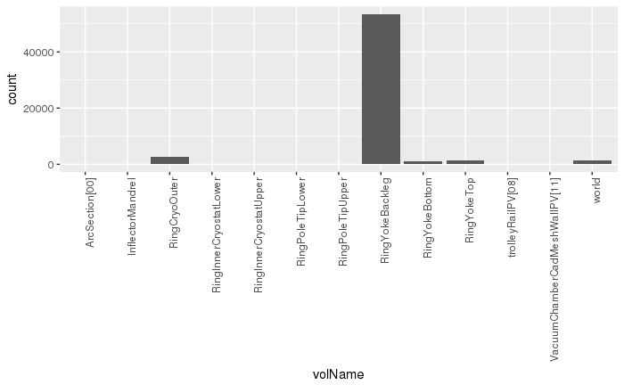

```r
taDeathDF %>% ggplot( aes(x = volName) ) + geom_bar() + theme(axis.text.x = element_text(angle=90, hjust=1))
```

## Look at Renee’s cylinder hits (this is the cylinder just in the outer wall of the vacuum chamber and around the inflector).

```r
useDataProduct('std::vector<gm2truth::GhostDetectorArtRecord>')
ghostCylinderInputTag = artInputTag('artg4:GhostCylinderDetector')
```

Create a reader class (modify outside of this notebook) for GhostDetectorArtRecord

```r
readerClassSkel('gm2truth::GhostDetectorArtRecord', writeFile = 'ghostDetectorReader.py')
```

Here’s the reader class

```r
readr::read_file('ghostDetectorReader.py') %>% cat
```

[output not shown]

Make an instance

```r
ghostDetectorReaderClass <- createReaderClass_from_file('ghostDetectorReader.py')$GhostDetectorArtRecordReader
ghostDetectorReader = ghostDetectorReaderClass(ghostCylinderInputTag)
```

Load the data

```r
getGalleryData(arrFiles, ghostDetectorReader)
```

```r
gcDF <- galleryReader_df(ghostDetectorReader)
```

How many events did we get?

```r
nrow(gcDF)
```

[output not shown]

```r
head(gcDF)
```

[output not shown]

Make factors…

Some common particles are

```r
# See  http://pdg.lbl.gov/2007/reviews/montecarlorpp.pdf for PDG value meanings
pdgs <- c('e-'= 11, 'nu_e'= 12, 'mu-'= 13, 'nu_mu'= 14, 'tau-'= 15, 'nu_tau'= 16,
          'e+'=-11, 'anti_nu_e'=-12, 'mu+'=-13, 'anti_nu_mu'=-14, 'tau+'=-15, 'anti_nu_tau'=-16,
          'gam'=22, 'p'=2212, 'n'=2112, 'anti-p'=-2212, 'anti-n'=-2112)
pdgs
```

```r
gcDF %>% mutate(scenario = factor(fileEntry, levels=0:(length(scenarios)-1), labels=scenarios),
                pdg = factor(particleID, levels=pdgs, labels=names(pdgs))) %>%
  select(scenario, eventEntry, pdg, everything())-> gcDF
gcDF
```

How many lost per scenario

```r
gcDF %>% filter(pdg == 'mu+') %>% group_by(scenario) %>% tally()
```

[output not shown]

How many events?

```r
gcDF %>% group_by(scenario) %>% tally()
```

[output not shown]

# See evidence of escaping muons

We can see the muons that escape the vacuum chamber by looking at the ghost detector Hits from Renee’s detector (has art input tag of `artg4:GhostCylinderDetector`). We can also look at hits from my ghost detector that sits just inside the world cube.

## Load the data

Tell PyRoot to load the necessary dictionaries.

```r
readGalleryPy$provide_get_valid_handle('std::vector<gm2truth::GhostDetectorArtRecord>')
```

```r
gh_cyl_tag <- readGalleryPy$createInputTag('artg4:GhostCylinderDetector')
gh_nwd_tag <- readGalleryPy$createInputTag('artg4:GhostNearWorldDetector')
```

Let’s try to load data!

```r
pyClass = '
class GhostDetectorArtRecordReader:
  """Reader object to read Ghost Detector Art Record objects"""

  def __init__(self, inputTag):
    self.vals = []
    self.inputTag = inputTag
    self.getValidHandle = None
    self.names = ["fileEntry", "eventEntry", "particleID", "trackID", "parentTrackID", "x", "y", "z",
                "px", "py", "pz"]

  def colnames(self):
    return self.names

  def prepare(self, ROOT, ev):
    self.vals = []  # Protect againt re-run
    self.getValidHandle = ev.getValidHandle(ROOT.vector(ROOT.gm2truth.GhostDetectorArtRecord))

  def fill(self, ROOT, ev):
    gh_cyl_h = self.getValidHandle(self.inputTag)  # Get the valid handle
    if not gh_cyl_h.empty():                       # Does it have data?
      gh_cyl = gh_cyl_h.product()                  # Get the corresponding data product vector
      for g in gh_cyl:                             # Loop over elements and fill
        if g.trackID == 1 and g.parentTrackID == 0:
          self.vals.append(
            [ev.fileEntry(), ev.eventEntry(), g.particleID, g.trackID, g.parentTrackID,
            g.position.x(), g.position.y(), g.position.z(),
            g.momentum.x(), g.momentum.y(), g.momentum.z()
            ])
    return True
'

py_run_string(pyClass)
```

```r
ghCReader <- main$GhostDetectorArtRecordReader(gh_cyl_tag)
ghNReader <- main$GhostDetectorArtRecordReader(gh_nwd_tag)
readers   <- readGalleryPy$GalleryReaders(list(ghCReader, ghNReader))
```

Read the data

```r
readGalleryPy$getGalleryData(fileVec1, readers) -> times
```

Check out the time

```r
times$allTime
```

[output not shown]

```r
ghcdf <- as.data.frame(do.call(rbind, ghCReader$vals))
ghcdf[] <- lapply(ghcdf, unlist)
names(ghcdf) <- ghCReader$colnames()
ghcdf
```

```r
format(nrow(ghcdf), big.mark = ',')
```

[output not shown]

```r
ghndf <- as.data.frame(do.call(rbind, ghNReader$vals))
ghndf[] <- lapply(ghndf, unlist)
names(ghndf) <- ghNReader$colnames()
ghndf
```

```r
ghCReader$colnames()
```